# HLA Typing from Whole-Genome Sequencing

T1K and OptiType vs published HLA types · GIAB HG001 trio + 1000 Genomes

## Design

- **Samples:** 24 genomes: GIAB HG001 (NA12878) from two independent data sets (NYGC 30x and GIAB 300x HiSeq downsampled to 30x), both CEPH parents, and 4 more samples from each 1000 Genomes super-population (AFR, AMR, EAS, EUR, SAS).
- **Reads:** only reads in the MHC (chr6:29.6-33.5 Mb) and on the HLA allele contigs are pulled from each remote CRAM/BAM.
- **Truth:** HLA types for the 1000 Genomes panel from Abi-Rached et al. 2018 (PLoS One 13:e0206512), typed from exomes with PolyPheMe. Ambiguous truth alleles (e.g. `03:01/04`) accept any listed allele.
- **Scoring:** for each locus the two called alleles are matched to the two truth alleles in whichever order gives the most matches. Accuracy = correct alleles / alleles typed in the truth.

## Accuracy

| Tool | Resolution | Correct | Alleles | Accuracy |
| --- | --- | --- | --- | --- |
| T1K | 1-field | 239 | 240 | 99.6% (97.7%-99.9%) |
| T1K | 2-field | 237 | 240 | 98.8% (96.4%-99.6%) |
| OptiType | 1-field | 144 | 144 | 100.0% (97.4%-100.0%) |
| OptiType | 2-field | 143 | 144 | 99.3% (96.2%-99.9%) |

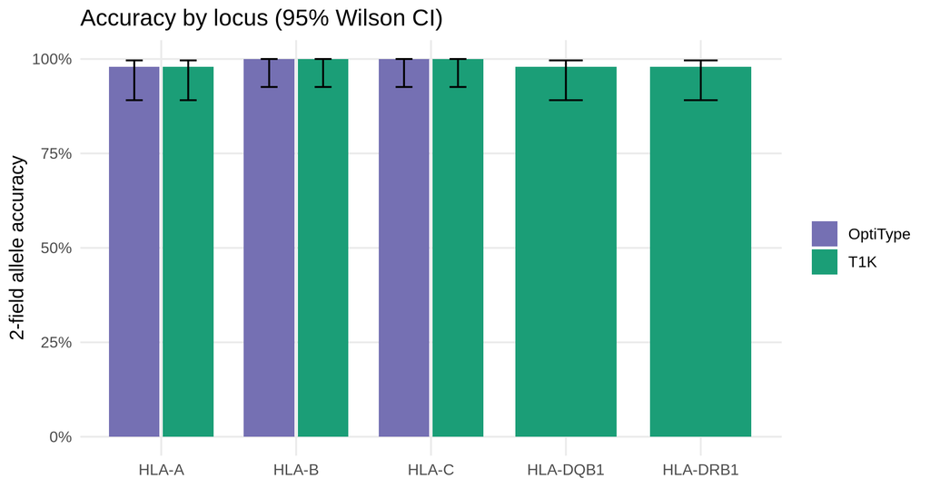

| Tool | Locus | Alleles | 1-field | 2-field |
| --- | --- | --- | --- | --- |
| T1K | HLA-A | 48 | 100.0% | 97.9% |
| T1K | HLA-B | 48 | 100.0% | 100.0% |
| T1K | HLA-C | 48 | 100.0% | 100.0% |
| T1K | HLA-DQB1 | 48 | 97.9% | 97.9% |
| T1K | HLA-DRB1 | 48 | 100.0% | 97.9% |
| OptiType | HLA-A | 48 | 100.0% | 97.9% |
| OptiType | HLA-B | 48 | 100.0% | 100.0% |
| OptiType | HLA-C | 48 | 100.0% | 100.0% |

## Accuracy by super-population

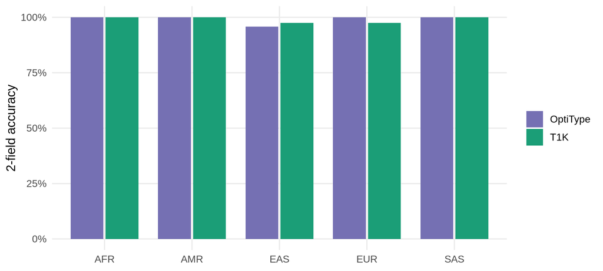

## T1K and OptiType agreement (class I)

| Locus | Samples | Both alleles agree | One allele agrees | Neither |
| --- | --- | --- | --- | --- |
| A | 24 | 100.0% | 0.0% | 0.0% |
| B | 24 | 100.0% | 0.0% | 0.0% |
| C | 24 | 100.0% | 0.0% | 0.0% |

## HG001 trio and data-set consistency

A child inherits one HLA haplotype from each parent, so NA12878’s alleles must be explainable by one allele from NA12891 and one from NA12892. This check needs no truth set.

| Tool | Locus | NA12878 | NA12891 (father) | NA12892 (mother) | Consistent |
| --- | --- | --- | --- | --- | --- |
| T1K | HLA-A | 11:01/01:01 | 01:01/24:02 | 11:01/02:01 | yes |
| T1K | HLA-B | 56:01/08:01 | 08:01/07:02 | 15:01/56:01 | yes |
| T1K | HLA-C | 07:01/01:02 | 07:01/07:02 | 01:02/04:01 | yes |
| T1K | HLA-DQB1 | 05:01/02:01 | 02:01/06:02 | 05:01/05:01 | yes |
| T1K | HLA-DRB1 | 01:01/03:01 | 03:01/15:01 | 01:01/01:01 | yes |
| OptiType | HLA-A | 01:01/11:01 | 01:01/24:02 | 02:01/11:01 | yes |
| OptiType | HLA-B | 08:01/56:01 | 07:02/08:01 | 15:01/56:01 | yes |
| OptiType | HLA-C | 01:02/07:01 | 07:01/07:02 | 01:02/04:01 | yes |

| Tool | Locus | GIAB 300x -> 30x | NYGC 30x |
| --- | --- | --- | --- |
| T1K | A | 11:01/01:01 | 11:01/01:01 |
| T1K | B | 08:01/56:01 | 56:01/08:01 |
| T1K | C | 01:02/07:01 | 07:01/01:02 |
| T1K | DRB1 | 01:01/03:01 | 01:01/03:01 |
| T1K | DQB1 | 05:01/05:03 | 05:01/02:01 |
| OptiType | A | 01:01/11:01 | 01:01/11:01 |
| OptiType | B | 08:01/56:01 | 08:01/56:01 |
| OptiType | C | 01:02/07:01 | 01:02/07:01 |

## Errors

| Sample | Region | Tool | Locus | Called | Truth | Correct (2-field) | Correct (1-field) |
| --- | --- | --- | --- | --- | --- | --- | --- |
| NA18618 | EAS | OptiType | A | 02:01/24:02 | 02:01/24:01 | 1 | 2 |
| NA18618 | EAS | T1K | A | 24:02/02:01 | 02:01/24:01 | 1 | 2 |
| HG001_GIAB | EUR | T1K | DQB1 | 05:01/05:03 | 02:01/05:01 | 1 | 1 |
| HG01631 | EUR | T1K | DRB1 | 03:01/04:14 | 03:01/04:02 | 1 | 2 |

## Limitations

- The truth set was itself produced computationally (from exomes, IMGT/HLA 3.28). Some disagreements will be errors in the truth, especially where the truth is homozygous or ambiguous.
- 24 samples give wide confidence intervals per locus. A clinical HLA validation would use more samples typed by an orthogonal lab method (SSO/SBT) and would report G-group resolution.
- OptiType only types class I. Neither tool is used here for HLA-DPB1, -DQA1 or -DRB3/4/5, because the truth set does not cover them.